# Data Science Project EDA

Kaylee Davis

2023-12-12

# Introduction

As societies grow more reliant on technology and machine learning, understanding public sentiment is crucial for responsible development and implementation. This report delves into the dynamics of technology adoption and recommendation behaviors across diverse demographic groups. It focuses on understanding how different factors, specifically, age and household income, influence individuals’ appraisals of technology, focusing on concerns toward technology In general, insights regarding population-level perceptions of technology are crucial for stakeholders such as marketers, policymakers, and tech developers, highlighting the importance of tailoring strategies to effectively reach specific demographic segments. By pinpointing various predictors of adoption behavior and technology concern, the dataset offers valuable guidance for developing targeted, inclusive policies and educational initiatives to foster digital literacy and bridge adoption gaps.

### Research Questions

Q1: Whether age-group affects appraisals of technology Q2: Whether income-level negatively affects an individuals appraisals of technology (lower = more neg)

# Method

The study utilized a quantitative methodology, analyzing data from an online dataset acquired from kaggle. The dataset examined technology use, concerns, influences, barriers to adoption, and likelihood of recommending emerging technologies. This dataset is utilized to determine if age or income level might predict skepticism toward technology. However, after conducting statistical tests and using descriptive statistics to visualize the relationship, there was no significant effect for these predictions.

I used the Technology Perception Survey dataset to investigate these questions. This dataset is relevant due to its focus on demographic variables (age, socioeconomic status, etc.) and attitudes towards technology (barriers to adoption, likeliness to adopt, etc.) The data was obtained from the Kaggle website and generated by an individual named Calvin White.

The dataset examined technology use, concerns, influences, barriers to adoption, and likelihood of recommending emerging technologies. This dataset is utilized to determine if age or income level might predict skepticism toward technology. The group surveyed were individuals living in India. Their responses provided insights into their usage, concerns, influence, barriers, and likelihood to adopt and recommend technologies as the original intended use of the dataset is to understand consumer behavior and gain insights into how different demographic groups perceive and interact with technology. The comprehensiveness and focus on technology perception provide a rich basis for analysis. While the dataset seems to be collected without apparent bias from the researcher, a major limitation of the study is that the sample is largely from India, making it unrepresentative of global consumer household tendencies. Additionally, there is an overrepresentation of male participants in the sample. This lack of representation could lead to potential blind spots in understanding how different groups perceive and interact with technology.

Necessary Transformations: I created additional variables that consolidate some of the categories to streamline the data, making it more conducive to deeper analysis. In the report provided by the author, this is a similar strategy they took when analyzing the data. I used descriptive statistics and data visualization to get an overarching view of the trends and interactions between variables of interest

# Results

Figure 3 displays the age and gender distribution of participants. This distribution provides insights into the gender representation within the study and enables the examination of potential gender-related differences in technology adoption behavior. Additionally, Figure 3 shows that the sample consists of individuals from various age groups, allowing for a comprehensive analysis of technology adoption behaviors across different life stages. However, as noted before, the sample is predominantly male, which makes it harder to generalize findings.

In Figure 4, statistical analysis suggests no significant difference in TotalTechConcern among age groups (p > 0.05). This suggests that age alone is not be a strong determining factor in individuals’ TotalTechConcern. Other factors, such as technological familiarity, personal experiences, and individual preferences, may have a more significant influence on individuals’ perceived concerns or risks associated with technology.

Figure 5 aims to answer whether income level might negatively affect an individual’s appraisals of technology. There was no statistical correlation found, this implies that household income alone may not be a strong determining factor of their concerns toward technology.

### Setup

```r
# Using renv restore function to get dependencies
library(renv)
restore()

#Load required packages
library(ggplot2)
library(dplyr)
library(readr)
library(here)
library(skimr)
library(here)
library(tidyverse)
library(knitr)
library(tinytex)
```

### Read in data

```r
library(readr)
library(here)
SurveyData <- read_csv(here("data","SurveyData.csv"), show_col_types = FALSE)
```

### Check the packaging

```r
library(skimr)

skim(SurveyData)
```

Data summary

| Name | SurveyData |
| --- | --- |
| Number of rows | 107 |
| Number of columns | 36 |
| _______________________ |  |
| Column type frequency: |  |
| character | 3 |
| numeric | 33 |
| ________________________ |  |
| Group variables | None |

**Variable type: character**

| skim_variable | n_missing | complete_rate | min | max | empty | n_unique | whitespace |
| --- | --- | --- | --- | --- | --- | --- | --- |
| Gender | 0 | 1 | 4 | 6 | 0 | 2 | 0 |
| EducationLevel | 0 | 1 | 9 | 20 | 0 | 4 | 0 |
| IncomeCategory | 0 | 1 | 10 | 20 | 0 | 5 | 0 |

**Variable type: numeric**

| skim_variable | n_missing | complete_rate | mean | sd | p0 | p25 | p50 | p75 | p100 | hist |
| --- | --- | --- | --- | --- | --- | --- | --- | --- | --- | --- |
| Age | 0 | 1 | 40.38 | 13.58 | 19 | 25.0 | 45 | 5.05e+01 | 7.3e+01 | ▇▂▇▅▁ |
| HouseholdIncome | 0 | 1 | 3080671.42 | 6906289.85 | 15000 | 500000.0 | 900000 | 2.00e+06 | 5.0e+07 | ▇▁▁▁▁ |
| Frequency_LaptopDesktop | 0 | 1 | 3.52 | 1.90 | 0 | 2.0 | 4 | 5.00e+00 | 5.0e+00 | ▃▁▁▃▇ |
| Frequency_Smartphone | 0 | 1 | 4.22 | 1.57 | 0 | 4.0 | 5 | 5.00e+00 | 5.0e+00 | ▁▁▁▂▇ |
| Frequency_Tablet | 0 | 1 | 1.94 | 1.83 | 0 | 0.0 | 2 | 3.00e+00 | 5.0e+00 | ▇▂▃▂▂ |
| Frequency_SmartHomeDevices | 0 | 1 | 2.88 | 1.90 | 0 | 1.0 | 3 | 4.50e+00 | 5.0e+00 | ▇▂▃▆▇ |
| Frequency_WearableDevices | 0 | 1 | 2.31 | 2.09 | 0 | 0.0 | 2 | 4.50e+00 | 5.0e+00 | ▇▂▁▂▅ |
| Frequency_GamingConsoles | 0 | 1 | 1.40 | 1.72 | 0 | 0.0 | 0 | 3.00e+00 | 5.0e+00 | ▇▂▂▂▁ |
| Frequency_HomeSecuritySystem | 0 | 1 | 1.53 | 1.83 | 0 | 0.0 | 1 | 3.00e+00 | 5.0e+00 | ▇▂▂▁▂ |
| LikelinessToAdopt | 0 | 1 | 4.01 | 1.03 | 1 | 3.0 | 4 | 5.00e+00 | 5.0e+00 | ▁▁▃▇▇ |
| Benefit_ProductivityEfficiency | 0 | 1 | 3.83 | 1.07 | 1 | 3.0 | 4 | 5.00e+00 | 5.0e+00 | ▁▁▃▇▅ |
| Benefit_CommunicationConnectivity | 0 | 1 | 4.06 | 1.04 | 1 | 4.0 | 4 | 5.00e+00 | 5.0e+00 | ▁▁▂▇▇ |
| Benefit_EasyAccessToInfo | 0 | 1 | 4.24 | 1.08 | 1 | 4.0 | 5 | 5.00e+00 | 5.0e+00 | ▁▁▂▅▇ |
| Benefit_Entertainment | 0 | 1 | 4.10 | 1.01 | 1 | 4.0 | 4 | 5.00e+00 | 5.0e+00 | ▁▁▃▇▇ |
| Risk_SecurityPrivacy | 0 | 1 | 3.82 | 1.11 | 1 | 3.0 | 4 | 5.00e+00 | 5.0e+00 | ▁▂▃▇▆ |
| Risk_ExcessScreenTime | 0 | 1 | 3.83 | 1.07 | 1 | 3.0 | 4 | 5.00e+00 | 5.0e+00 | ▁▂▃▇▆ |
| Risk_ComplicatedToUse | 0 | 1 | 2.82 | 1.15 | 1 | 2.0 | 3 | 4.00e+00 | 5.0e+00 | ▃▇▇▅▂ |
| Risk_Addiction | 0 | 1 | 3.42 | 1.23 | 1 | 3.0 | 3 | 4.00e+00 | 5.0e+00 | ▂▅▇▇▇ |
| Risk_Health | 0 | 1 | 3.47 | 1.23 | 1 | 3.0 | 4 | 4.50e+00 | 5.0e+00 | ▂▅▇▇▇ |
| Risk_LossOfConnection | 0 | 1 | 3.68 | 1.18 | 1 | 3.0 | 4 | 5.00e+00 | 5.0e+00 | ▂▂▆▇▇ |
| Influence_FamilyFriends | 0 | 1 | 3.23 | 1.17 | 1 | 3.0 | 3 | 4.00e+00 | 5.0e+00 | ▂▃▇▇▃ |
| Influence_PromoActivities | 0 | 1 | 3.06 | 1.11 | 1 | 2.0 | 3 | 4.00e+00 | 5.0e+00 | ▂▃▇▅▂ |
| Influence_SocialPopularity | 0 | 1 | 3.13 | 1.17 | 1 | 2.0 | 3 | 4.00e+00 | 5.0e+00 | ▂▅▇▇▃ |
| Influence_ExpertRecommendation | 0 | 1 | 3.50 | 1.16 | 1 | 3.0 | 4 | 4.00e+00 | 5.0e+00 | ▂▂▅▇▃ |
| Influence_Endorsements | 0 | 1 | 2.39 | 1.22 | 1 | 1.0 | 2 | 3.00e+00 | 5.0e+00 | ▇▇▅▅▂ |
| Barrier_HighPrice | 0 | 1 | 3.35 | 1.34 | 1 | 2.0 | 3 | 5.00e+00 | 5.0e+00 | ▃▅▇▆▇ |
| Barrier_TechKnowledge | 0 | 1 | 2.55 | 1.28 | 1 | 1.0 | 3 | 3.00e+00 | 5.0e+00 | ▇▆▇▃▂ |
| Barrier_PrivacySecurity | 0 | 1 | 3.40 | 1.33 | 1 | 2.0 | 4 | 5.00e+00 | 5.0e+00 | ▃▅▇▇▇ |
| Barrier_ReliableInternet | 0 | 1 | 2.80 | 1.34 | 1 | 2.0 | 3 | 4.00e+00 | 5.0e+00 | ▇▆▇▇▃ |
| Barrier_ChangeReluctance | 0 | 1 | 2.42 | 1.16 | 1 | 1.0 | 2 | 3.00e+00 | 5.0e+00 | ▇▇▇▅▁ |
| LikelinessToRecommend | 0 | 1 | 3.90 | 1.14 | 1 | 3.0 | 4 | 5.00e+00 | 5.0e+00 | ▁▁▅▇▇ |
| TotalTechConcern | 0 | 1 | 21.05 | 5.59 | 6 | 18.0 | 22 | 2.50e+01 | 3.0e+01 | ▁▂▅▇▃ |
| TotalTechBenefit | 0 | 1 | 16.23 | 3.76 | 4 | 15.5 | 17 | 1.90e+01 | 2.0e+01 | ▁▁▂▃▇ |

107 rows, 36 columns Data is 100% complete, no concern over missing values

### Look at the top and the bottom of the data

```r
library(skimr)

if (interactive()) {
  View(head(SurveyData))
  View(tail(SurveyData))
  View(SurveyData)
}
```

### Created Variables and Relevant Overview Plots

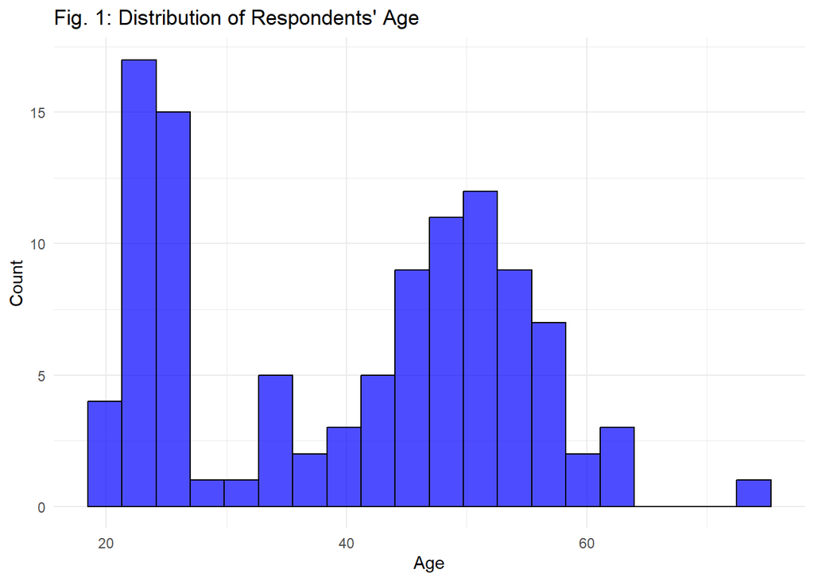

```r
library(ggplot2)

# Age distribution Histogram
ggplot(SurveyData, aes(x = Age)) +
  geom_histogram(
    bins = 20,
    fill = "blue",
    color = "black",
    alpha = 0.7
  ) +
  labs(x = "Age", y = "Count", title = "Fig. 1: Distribution of Respondents' Age") +
  theme_minimal()
```

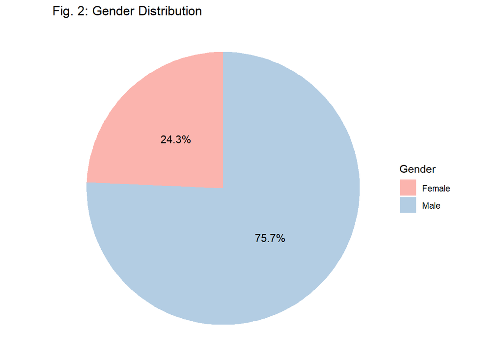

```r
library(ggplot2)
library(dplyr)
# Gender distribution pie chart
SurveyData %>%
  count(Gender) %>%
  ggplot(aes(x = "", y = n, fill = Gender)) +
  geom_bar(stat = "identity", width = 1) +
  coord_polar("y", start = 0) +
  scale_fill_brewer(palette = "Pastel1") +
  theme_void() +
  labs(title = "Fig. 2: Gender Distribution") +
  geom_text(aes(label = scales::percent(n / sum(n), accuracy = 0.1)),
    position = position_stack(vjust = 0.5)
  )
```

```r
# Calculating mean and median age
mean_age <-
  mean(SurveyData$Age, na.rm = TRUE) # na.rm = TRUE ensures that NA values are removed
median_age <- median(SurveyData$Age, na.rm = TRUE)

cat(sprintf("Mean Age: %.2f, Median Age: %.2f", mean_age, median_age))
```

```
## Mean Age: 40.38, Median Age: 45.00
```

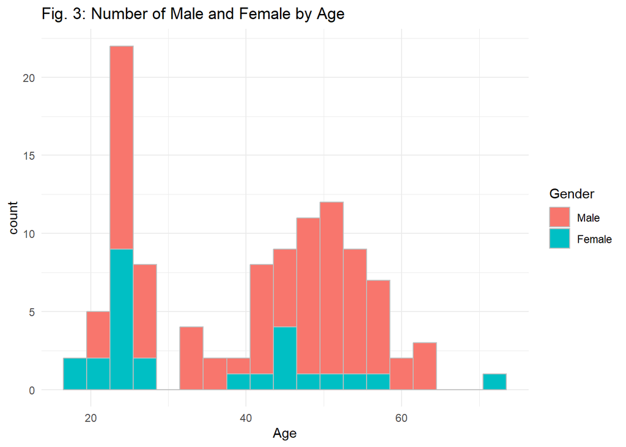

```r
library(ggplot2)

# Histogram plot of Age with color based on Gender
SurveyData$Gender <- factor(SurveyData$Gender, levels = c("Male", "Female"))

ggplot(data = SurveyData, aes(x = Age, fill = Gender)) +
  geom_histogram(
    position = "stack",
    binwidth = 3,
    colour = "grey"
  ) +
  labs(title = "Fig. 3: Number of Male and Female by Age") +
  theme_minimal()
```

Age and gender distribution of participants. The analysis reveals that the majority of participants identified as male, accounting for 75.7% of the sample. The remaining 24.3% of the participants identified as female. Furthermore, the analysis reveals a diverse range of ages, with peaks around 20-25 and 45-50

### Income Category Variable Created

```r
# Define labels for the income categories
breaks <- c(0, 200000, 600000, 1200000, 2000000, Inf)
labels <-
  c(
    "Low Income",
    "Lower-Middle Income",
    "Middle-Middle Income",
    "Upper-Middle Income",
    "High Income"
  )

# Create the IncomeCategory variable
SurveyData$IncomeCategory <-
  cut(
    SurveyData$HouseholdIncome,
    breaks = breaks,
    labels = labels,
    include.lowest = TRUE
  )
```

### Variable for TotalTechConcern Created

```r
# TotalTechConcern calculated by summing all columns that start with 'Risk'
SurveyData <- SurveyData %>%
  mutate(TotalTechConcern = rowSums(select(., starts_with("Risk"))))
```

### Variable for TotalTechBenefit Created

```r
# Calculate the TotalTechBenefit by summing all columns that start with 'Benefit'
SurveyData <- SurveyData %>%
  mutate(TotalTechBenefit = rowSums(select(., starts_with("Benefit")), na.rm = TRUE))
```

### Plots that look at the questions

Plotting the correlation between Age and TotalTechConcern Relevant Question: Does age-group affect appraisals of technology?

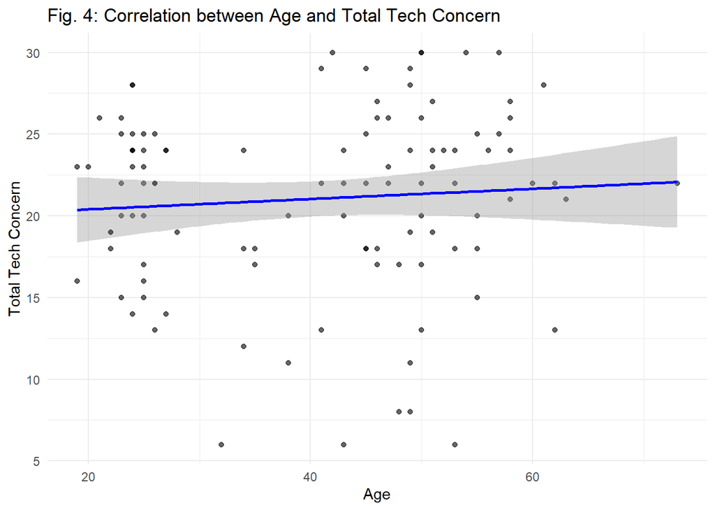

```r
library(ggplot2)

ggplot(data = SurveyData, aes(x = Age, y = TotalTechConcern)) +
  geom_point(alpha = 0.6) +
  geom_smooth(method = "lm", color = "blue") +
  labs(
    x = "Age", y = "Total Tech Concern",
    title = "Fig. 4: Correlation between Age and Total Tech Concern"
  ) +
  theme_minimal()
```

```r
# Calculate and print the correlation coefficient
correlation <-
  cor.test(SurveyData$Age, SurveyData$TotalTechConcern, use = "complete.obs") # use handles missing values
print(correlation)
```

```
##
##  Pearson's product-moment correlation
##
## data:  SurveyData$Age and SurveyData$TotalTechConcern
## t = 0.78713, df = 105, p-value = 0.433
## alternative hypothesis: true correlation is not equal to 0
## 95 percent confidence interval:
##  -0.1149389  0.2626302
## sample estimates:
##        cor
## 0.07659085
```

Correlation between age and technology concern. Total Technology Concern is calculated by summing up all variables associated with questions about technology risk. Specifically, It represents the total concern score for each respondent, considering multiple risks associated with technology adoption

### Plotting the relationship between IncomeCategory and TotalTechConcern

Relevant Question: Whether income-level negatively affects an individuals appraisals of technology (lower = more neg)

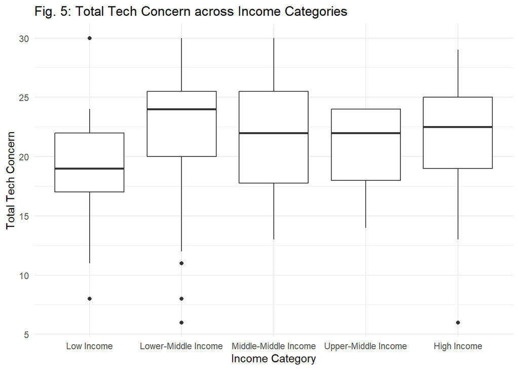

```r
library(ggplot2)

ggplot(data = SurveyData, aes(x = IncomeCategory, y = TotalTechConcern)) +
  geom_boxplot() +
  labs(
    x = "Income Category", y = "Total Tech Concern",
    title = "Fig. 5: Total Tech Concern across Income Categories"
  ) +
  theme_minimal()
```

```r
# ANOVA to test if differences in TotalTechConcern are statistically significant across IncomeCategory
anova_result <- aov(TotalTechConcern ~ IncomeCategory, data = SurveyData)
summary(anova_result)
```

```
##                 Df Sum Sq Mean Sq F value Pr(>F)
## IncomeCategory   4    100   24.92   0.792  0.533
## Residuals      102   3211   31.48
```

Relationship between income and technology concerns. Statistical analysis suggests no significant difference in TotalTechConcern among the income groups (p > 0.05). Income values are divided into five categories: Low Income (0 to 200,000), Lower-Middle Income (200,001 to 600,000), Middle-Middle Income (600,001 to 1,200,000), Upper Middle (1,200,001 to 2,000,000) Income, and High Income (Above 2,000,000). Each respondent is assigned an income category label based on their household income range.

# Discussion

P > 0.05 (No significant effect) for both observations. Therefore, income-level and age-group does not correlate with an individuals appraisals of technology.

Problem of Gender Imbalance: To counter the overrepresentation of male participants, future iterations of the survey could aim for a more balanced gender representation.

Diversifying Geographic Representation: The data is gathered from participants residing in India. As a result, generalizability is called into question. Conducting the survey in different countries or regions would provide comparative insights and reveal whether the trends observed are specific to India or more universally applicable.

Fit for Purpose: The data aligns well with the specific research questions I have, however, the sample representativeness is a weak point of the data. generalizability is not possible with this data, therefore, it is not fit for purpose. Regardless, the data provides a good starting point.